# DWEI5_Aula09_JS-EstruturasDecisao-Repeticao

Instituto Federal de São Paulo (IFSP)  
[Campus Bragança Paulista/SP](https://bra.ifsp.edu.br)  
**Análise e Desenvolvimento de Sistemas (ADS)**  
**5o. módulo**  
**Profa. Ana Paula Müller Giancoli**  
paulagiancoli@ifsp.edu.br

## AULA 09 - JAVASCRIPT ESTRUTURAS DE DECISÃO E REPETIÇÃO

### Agenda

- Estruturas de Decisão
- Estruturas de Repetição
- Perguntas

### 1. Estruturas de Decisão

- De acordo com [MDN Web Docs], "em qualquer linguagem de programação, o código precisa tomar decisões e realizar ações de acordo, dependendo de diferentes entradas".
- Para aprofundamento consulte [MDN Web Docs](https://developer.mozilla.org/pt-BR/docs/Aprender/JavaScript/Elementos_construtivos/conditionals).

### 1.1. Estruturas de Decisão Simples

- **Sintaxe**:
  - A **palavra reservada if** seguida de um par de parênteses ( ), onde a condição deverá ser indicada, e as linhas de código serão inseridas entre as chaves { }.

```
if (condição) {
    ... linhas de código finalizadas com ponto e vírgula;
}
```

### 1.2. Estruturas de Decisão Composta

- **Sintaxe**:
  - A **palavra reservada if** seguida de um par de parênteses ( ), onde a condição deverá ser indicada, e as linhas de código serão inseridas entre as chaves { }.
  - E a **palavra reservada else** seguida de chaves { }, onde serão informadas as demais linhas de código, caso seja falso o teste da condição.

```
if (condição) {
    ... linhas de código finalizadas com ponto e vírgula;
} else {
     ... linhas de código finalizadas com ponto e vírgula;
}
```

### 1.3. Estruturas de Decisão Encadeada

- **Sintaxe**:

```
if (condição1) {
    ... serão executadas as linhas de código caso condição1 seja verdadeira;
} else if (condição2) {
     ... serão executadas as linhas de código caso condição1 falsa e a condição2 seja verdadeira;
} else if (condição3) {
     ... serão executadas as linhas de código caso condição1, condição2 falsas e a condição3 seja verdadeira;
} else if (condição4) {
     ... serão executadas as linhas de código caso condição1, condição2, condição3 falsas e a condição4 seja verdadeira;
} else {
     ... serão executadas as linhas de código caso todas as condições anteriores foram falsas;
}
```

- **Exemplo**:

```
<!DOCTYPE html>
<html lang="pt-br">
<head>
    <meta charset="UTF-8">
    <title>Estruturas de Decisão</title>
</head>
<body>
    <script>
      let d = new Date();
      let h = d.getHours();
      if (h >= 0 && h <= 12) {
        console.log("Bom dia!!!");
      } else if (h <= 18) {
        console.log("Bom tarde!!!");
      } else if (h > 18) {
        console.log("Boa noite!!");
      }
    </script>
</body>
</html>
```

### 1.2 Switch Case

- De acordo com [MDN Web Docs](https://developer.mozilla.org/pt-BR/docs/Aprender/JavaScript/Elementos_construtivos/conditionals), "As instruções if ... else possuem suas desvantagens. Elas são boas principalmente para casos em que você tem algumas opções, e cada uma requer uma quantidade razoável de código para ser executado, e / ou as condições são complexas (por exemplo, vários operadores lógicos)".
- Ainda segundo [MDN Web Docs], "nos casos em que você deseja definir uma variável para uma determinada opção de valor ou imprimir uma determinada instrução dependendo de uma condição, a sintaxe pode ser um pouco incômoda, especialmente se você tiver um grande número de opções".
- **Sintaxe**:

```
switch (expressão) {
    case rotulo1:
        .... declarações;
        break;
    case rotulo2:
        .... declarações;
        break;
    case rotulo3:
        .... declarações;
        break;

    default:
        .... declarações;
        break;
}
```

- A **palavra reserva switch** utiliza uma única expressão / valor como uma entrada e, em seguida, examinam várias opções até encontrarem um que corresponda a esse valor, executando o código correspondente que o acompanha.
- A **palavra reservada switch** seguida de um par de parênteses ( ), onde a expressão deverá ser indicada, e as chaves { }, que **conterão cada uma das escolhas**, por meio do uso da **palavra reservada case** seguida da escolha **rótulo** **:**, onde serão informadas as demais linhas de código, caso seja verdadeiro a escolha da expressão.
- O **break;** serve para **interromper o bloco** e seguirá normalmente nas linhas de código fora do switch.
- **Exemplo**:

```
<!DOCTYPE html>
<html lang="pt-br">
<head>
    <meta charset="UTF-8">
    <title>Estruturas de Decisão</title>
</head>
<body>
    <script>
       tipoFruta = prompt("Indique um tipo de fruta: ");
       switch (tipoFruta) {
         case "laranja":
           console.log("O preço da " + tipoFruta + " é R$ 5.00.");
           break;
         case "P\pera":
           console.log("O preço da " + tipoFruta + " é R$ 5.00.");
           break;
         case "abacaxi":
           console.log("O preço da " + tipoFruta + " é R$ 5.00.");
           break;
         case "abacate":
           console.log("O preço da " + tipoFruta + " é R$ 5.00.");
           break;
          default:
            console.log("Não temos esta fruta!!");
            break;
       }
       console.log("Gostaria de mais alguma coisa?");
    </script>
</body>
</html>
```

### 1.3. Operador Ternário

- O **operador ternário** testa uma condição e retorna um valor / expressão se for verdadeira e outro caso seja falso. Muito útil no caso de pouco código a escrever.
- **Sintaxe**:

  ```
  (condição) ? resposta ao teste verdadeiro :  resposta ao teste falso;
  ```

- **Exemplo**:

```
<!DOCTYPE html>
<html lang="pt-br">
<head>
    <meta charset="UTF-8">
    <title>Estruturas de Decisão</title>
</head>
<body>
    <script>
            let tipoFruta = prompt("Indique o tipo de fruta: ");
            let resultado = tipoFruta == "Abacaxi" ? "Acertou o tipo de fruta!" : "Errou o tipo, tente novamente!";
            console.log(resultado + "!!");
    </script>
</body>
</html>
```

### 2. Estruturas de Repetição

- For...
- Do... while
- While ...
- For ... in ...
- For ... of ...

### 2.1. For

- Um laço **for** é repetido até que a condição especificada seja falsa.
- O laço **for** no JavaScript é similar ao Java e C.
- Uma **declaração for** é feita da seguinte maneira:

```
for (declaração; condição; passos) {
  ... declarações
}
```

- **Exemplo**:

```
<!DOCTYPE html>
<html>
<head>
  <meta charset="utf-8">
  <title>JS_FOR</title>
</head>
<body>
    <form name="selectForm">
      <p>
        <label for="tipoMusica">Escolha alguns tipos de música, em seguida, clique no botão abaixo:</label>
        <select id="tipoMusica" name="tipoMusica" multiple="multiple">
          <option selected="selected">R&B</option>
          <option>Jazz</option>
          <option>Blues</option>
          <option>New Age</option>
          <option>Classico</option>
          <option>Ópera</option>
        </select>
      </p>
      <p><input id="btn" type="button" value="Quantos foram selecionados?" /></p>
    </form>

    <script>

        function howMany(selectObject) {
          var numeroSelecionadas = 0;
          for (var i = 0; i < selectObject.options.length; i++) {
            if (selectObject.options[i].selected) {
              numeroSelecionadas++;
            }
          }
          return numeroSelecionadas;
        }

        var btn = document.getElementById("btn");
        btn.addEventListener("click", function(){
          alert('Total de opções selecionadas: ' + howMany(document.selectForm.tipoMusica))
        });
    </script>
</body>
</html>
```

### 2.2. Do ... While

- Um laço **Do ... While** é repetido até que a condição especificada seja falsa.
- **Executa pelo menos uma vez**, antes de testar a condição.

```
do {
  ... declarações;
} while (condição);
```

- **Exemplo**:

```
<!DOCTYPE html>
<html>
<head>
    <meta charset="utf-8">
    <title>JS_DO-WHILE</title>
</head>
<body>
    <script>
        i = 0;
        do {
          i += 1;
          console.log(i);
        } while (i < 5);
    </script>
</body>
</html>
```

### 2.3. While

- Uma declaração **While** executa suas instruções, desde que uma condição especificada seja avaliada como verdadeira.
- Se a **condição se tornar falsa**, a declaração dentro do laço para a execução e o controle é passado para a instrução após o laço.
- O teste da condição ocorre antes que o laço seja executado:  
  a) se a condição for verdadeira o laço executará e testará a condição novamente.  
  b) se a condição for falsa o laço termina e passa o controle para as instruções após o laço.

```
while (condição) {
  ... declarações;
}
```

- **Exemplo**:

```
<!DOCTYPE html>
<html>
<head>
    <meta charset="utf-8">
    <title>JS_WHILE</title>
</head>
<body>
    <script>
        n = 0;
        x = 0;
        while (n < 3) {
          n++;
          x += n;
        }
        console.log(n);
        console.log(x);
    </script>
</body>
</html>
```

### 2.7. For ... In

- A declaração **for ... in** executa iterações a partir de uma variável específica, percorrendo todas as propriedades de um objeto ou array.
- **Sintaxe**:

```
for (variavel in objeto) {
    ... declarações
}
```

- **Exemplo**:

```
<!DOCTYPE html>
<html>
<head>
    <meta charset="utf-8">
    <title>JS_FOR-IN</title>
</head>
<body>
    <script>
        /*Então executará uma iteração para cada elemento e retornará uma lista de string, que irá conter o nome da propriedade e seu valor. */
        function dump_props(obj, obj_name) {
            var result = "";
            for (var i in obj) {
              result += obj_name + "[" + i + "] = " + obj[i] + "\n";
            }
            result += "****";
            return result;
          }

         console.log(dump_props([1, 2, 3, 4], 'item'));
    </script>
</body>
</html>
```

### 2.8. For ... Of

- A declaração **for ... of** cria uma laço com objetos interativos (incluindo, array, map, set, assim por conseguinte), executando uma iteração para o valor de cada propriedade distinta.
- **Sintaxe**:

```
for (variavel of objeto) {
    ... declarações
}
```

- **Exemplo**:

```
<!DOCTYPE html>
<html>
<head>
    <meta charset="utf-8">
    <title>JS_FOR-OF</title>
</head>
<body>
    <script>
        /* O exemplo a seguir mostra a diferença entre o for...of e o for...in.
        Enquanto o for...in interage com o nome das propriedades, o for...of interage com o valor das propriedades. */
        let arr = [3, 5, 7];
        arr.foo = "hello";

        for (let i in arr) {
           console.log(i); // logs "0", "1", "2", "foo"
        }

        for (let i of arr) {
           console.log(i); // logs "3", "5", "7"
        }
    </script>
</body>
</html>
```

#### 1. Elabore um programa que exiba um caracter em x quantidade de linhas. Aumentando a repetição conforme a linha.

```
x = prompt("Indique o caracter: ");
y = prompt("Indique a quantidade de linhas: ");
exibirCaracter(x, y);

function exibirCaracter(texto, linhas) {
    for(let l=1; l <= linhas; l++) {
        let desenho = '';
        for(let m=0; m < l; m++) {
            desenho += texto;
        }
        console.log(desenho);
    }

}
```

- **Saída**:

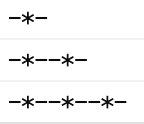

#### 2. Iterando em um Array

```
let inicio = [ 'a', 'b', 'c', 'd'];

// Utilizando for .. of
for (letras of inicio) {
    console.log(letras);
}
```

```
let inicio = [ 'a', 'b', 'c', 'd'];

// Utilizando for .. in
for (letras1 in inicio) {
    console.log(letras1);
}
```

```
let inicio = [ 'a', 'b', 'c', 'd'];

// Utilizando forEach
inicio.forEach(element => {
    console.log(element);
});
```

- **Saída**:

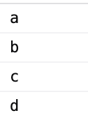

#### 3. Outros exemplos

```
const valores = [1, 3, 5, 7, 9];

const uniao = valores.join('.');
console.log(uniao);

const url = "https://pt.stackoverflow.com/questions/242578/erro-no-javascript";
const parametros = url.split("/");
console.log(parametros);

const diversos = "O uso de Javascript no dia a dia";
const separar = diversos.split(" ");
console.log(separar);
const urlFinal = separar.join('-');
console.log(urlFinal);
```

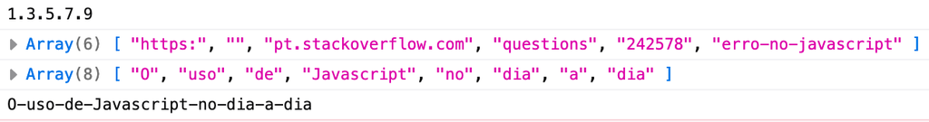

### Referências

- Esta aula foi elaborada a partir do conteúdo disponibilizado em cada um dos links indicados no próprio texto.

### Perguntas

- Esclareça suas eventuais dúvidas durante as aulas.
- Ou pelo *E-mail*: paulagiancoli@ifsp.edu.br.
- Ou pelo *Fórum* do componente curricular.

*ADS - HTML5, CSS3, JS - 5o. módulo*.  
Modelo e formato elaborado por profa. Ana Paula Müller Giancoli - BSD 2-Clause License. - Julho.2021.